# Risky and Safe Assets

back to [Fan](https://fanwangecon.github.io)'s [Intro Math for Econ](https://fanwangecon.github.io/Math4Econ/), [Matlab Examples](https://fanwangecon.github.io/M4Econ/), or [MEconTools](https://fanwangecon.github.io/MEconTools/) Repositories

## Uncertainty

Previously, we have solved the [household savings problem without uncertainty](https://fanwangecon.github.io/Math4Econ/derivative_application/K_save_households.html). Now, suppose there are 2 states of the world tomorrow, in one state of the world, the economy is booming, the other not so great.

If you deposited money into a savings account at Bank of America, your earnings in the good and bad states are likely to be very similar. Let's assume they are actually the same.

If you bought stocks, you might make a lot of money when the economy is booming, but lose money when the economy is not doing well. Let's assume you make higher return in the good state compared to return to savings at Bank of America, but you loss all investments in the bad state.

## Differential Returns Depending on the State of the World

Let us formalize things. A household can save $BOA$ in safe asset and for each dollar saved, get $1+r$ dollar tomorrow. Alternatively, a household can invest $DOW#$ in risky asset. In the good state of the world tomorrow, the household will receive $1+r_h$ back for each dollar invested. In the bad state of the world tomorrow, the household will receive nothing--lose all. The probability that the next period is good is $p_h$, and the probability that the next period is bad is $1-p_h$.

Note that:

- Households know what interest they will earn in the booming and non-booming economy
- They know the probability that we end in the booming and non-booming economy
- Uncertain: Even if the chance of having the good economy tomorrow is only $p_h = 0.01$, the household does not know in the current period whether for sure tomorrow will be a good or a bad period.

## The Two Period Household Protofolio Choice Problem

Suppose as before that we have log utility, β for the discount factor, $Z_1$ inheritance in the first period, and $Z_2$ inheritance in the second period, what is the maximization problem that households face? (Let D represent $DOW$ investment, and B represent $BOA$ savings.)

Utility

- $U = \log(c_1) + \beta \left(p_h \cdot \log (c_{2h}) + (1-p_h) \cdot \log(c_{2l}) \right)$

Budget Period 1:

- $c_1 + D + B= Z_1$

Budget Period 2:

- Good State: $c_{2h} = Z_2 + B \cdot (1+r) + D \cdot (1 + r_h)$
- Bad State: $c_{2l} = Z_2 + B \cdot (1+r)$

As noted, there is no return from risky asset in the bad state. And note that compared to our [Two Periods Saving/Borrowing without Shocks](https://fanwangecon.github.io/Math4Econ/derivative_application/K_save_households.html), there are two different consumptions tomorrow now. Only one state of the world will be realized tomorrow, but from today's perspective, we have to consider consumption under both possibilities. Also note that with log utility, households are risk averse.

## Household Maximization Problem

Let's use $R = 1+r$ and $R_h = 1 + r_h$

Our maximziation problem is:

- $\max_{D, B } \log(Z_1 - D - B) + \beta p_h \log\left[Z_2 + B\cdot R + D\cdot R_h \right] + \beta (1-p_h) \log\left[Z_2 + B\cdot R\right]$

Different combinations of D and B have these interpretations, for example:

1. If $D>0$ and$B>0$, that means you are saving in both the risky and safe assets at the same time. This is the classic portofolio choice problem. You want some optimal composition of risky and safe return assets. Some fraction of period 1 endowment (if it is higher than period 2 endowment) into Bank of America to have safe return, some fraction investin stocks, and consume the remaining fraction
2. If $D>0$ and $B<0$, return in DOW so attractive that you borrow from BOA to finance your stock purchases.
3. If $D=0$ and $B<0$, borrow from BOA to increase consumption today, but no risky investments.

Note that we given we allow D and B to be positive or negative. This means that potentially, you can also borrow D.

## First Order Conditions

We can take advantage of matlab's symbolic tool box as before, we can type up the utility function:

```matlab
syms Z1 Z2 D B beta ph R Rh
U = log(Z1 - D - B)  + beta * ph * log(Z2 + B*(R) + D*(Rh)) + beta*(1-ph)*log(Z2 + B*R )
```

U =

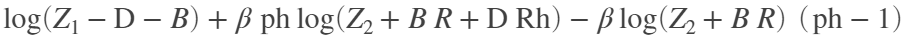

Now we can take derivative of U with respect to D and B:

```matlab
% MUC_{t} = E(MUC_{t+1}
diffUB = diff(U, B)
```

[output not shown]

diffUB =

```matlab
diffUD = diff(U, D)
```

diffUD =

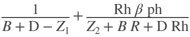

For optimal choice, we want to set the two first order conditions to be equal to zero.

## Marginal Utility and Marginal Returns

Partial derivative of U with respect to B (diffUB) has three terms:

1. $MUC_{1}$ = marginal utility of consumption $t=1$ (today)
2. $(MUC_{2h} \cdot R \cdot \beta \cdot p_h)$ = (marginal utility of consumption t=2 in boom) x (marginal return to safe asset) x (time discount) x (probability of good state)
3. $(MUC_{2l} \cdot R \cdot \beta \cdot (1-p_h))$ = (marginal utility of consumption t=2 in bust) x (marginal return to safe asset) x (time discount) x (probability of bad state)

Note that the sum of the second and third terms is:

- Expected return to saving safe asset: $(MUC_{2h} \cdot R \cdot \beta \cdot p_h)+(MUC_{2l} \cdot R \cdot \beta \cdot (1-p_h))$

Partial derivative of U with respect to D (diffUD) has two terms:

1. $MUC_{1}$ = marginal utility of consumption $t=1$ (today)
2. $(MUC_{2h} \cdot R_h \cdot \beta \cdot p_h)$ = (marginal utility of consumption t=2 in boom) x (marginal return to risky asset) x (time discount) x (probability of good state)

Note that the second term is the expected return to the risky asset.

## Solving for Optimal Choices--Analytical Solution

Using the symbolic toolbox, we now show the analytical solution to the problem as a function of the parameters

```matlab
% We have two first order conditions, set both to 0, solve for D and B
soluDB = solve(diffUD==0, diffUB==0, D, B)
```

soluDB = struct with fields:

D: [1×1 sym] B: [1×1 sym]

```matlab
soluD = soluDB.D
```

[output not shown]

soluD =

```matlab
soluB = soluDB.B
```

soluB =

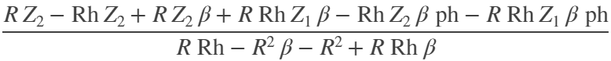

## Solving for Optimal Chocies--Numerical Parameter Values

If we have specific values for the parameters, we can find the exact optimal choices. In the example below below, we modify the problem slightly so that there could be positive return from stocks in the bad state of the world as well. Given our parameters, the optimal B choice is negative, and D choice is positive. This means the household is borrowing from Bank of America to finance investment in DOW. Change the parameters and see how the optimal portofolio of choices differ.

Is there an upper bound to this borrowing? Yes, the household knows that DOW investment will have no return in the bad state of the world, but BOA loans have to be paid bad in both the good and bad state. The household has $Z_2$ endowment in the next period for both good and bad states. The household will never borrow so much that he has no money left for consumption in the bad state after repaying debts, which he is required to given our model specifications. Specifically, the household will at most borrow up to $\frac{Z_2}{(1+r)}$. If the household borrows more than this, then upon arrival in the bad state of the world (regardless how small the probability of bad state is as long as it is greater than zero), the household will have equal or below zero resources left for consumption, where utility is not defined. This is also called the natural borrowing constraint.

```matlab
% Let's only have D and B as symbols
syms D B
% More endowment today than tomorrow, giving us incentives to save
Z1 = 10;
Z2 = 5;
beta = 1;
ph = 0.7;
R = 1;
% Modify the problem slightly so that there is positive return in the bad
% state. Modify this value and see what happens. Set Rl=0 for the
% previously stated problem where stocks have no returns in the bad state
% of the world.
Rh = 1.5;
Rl = 0.5;
% Retype what we had before:
U = log(Z1 - D - B)  + beta * ph * log(Z2 + B*(R) + D*(Rh)) + beta*(1-ph)*log(Z2 + B*R + D*(Rl));
% Our problem is solved using one line:
soluDB_numeric = solve(diff(U, D)==0, diff(U, B)==0, D, B);
soluD_numeric = double(soluDB_numeric.D)
```

soluD_numeric = 6

```matlab
soluB_numeric = double(soluDB_numeric.B)
```

soluB_numeric = -3.5000